# Python Fundamentals

Monday · Session 1

Diego A. Guerrero

GDP Growth Nowcasting Workshop · Trinidad and Tobago

# Learning Objectives

- Familiarize with the basic concepts of **Python**
- Identify and manipulate **data structures**
- Run and execute **Python notebooks**
- Perform **basic data uploading and cleaning**
- Compute **summary statistics** and visualize time series

# Introduction to Python

**Why Python?**

- Speed, reproducibility, flexibility, and a vast ecosystem of libraries
- Integrates with R, SQL, Excel, Stata, and APIs
- Scales from a small dataset to cloud-scale Big Data
- **Free** — no licensing costs for government use

### Key Libraries

- [pandas](https://pandas.pydata.org/) — data manipulation
- [numpy](https://numpy.org/) — numerical computing
- [matplotlib](https://matplotlib.org/) — static plots
- [seaborn](https://seaborn.pydata.org/) — statistical graphics
- [scikit-learn](https://scikit-learn.org/stable/) — machine learning
- [statsmodels](https://www.statsmodels.org/) — econometric models
- [openpyxl](https://openpyxl.readthedocs.io/) — Excel I/O
- [jupyter](https://jupyter.org) — interactive notebooks

## First Python Program

```python
print("Hello, Trinidad and Tobago!")
print(2 + 5)
```

```
Hello, Trinidad and Tobago!
7
```

# Python Syntax

## Variables and Types

```python
country = "Trinidad and Tobago"
gdp = 8_480       # USD millions (approximate)
growth_rate = 0.035
island = True

print(country, gdp)
print(growth_rate, island)
```

```
Trinidad and Tobago 8480
0.035 True
```

*Variables are stored in RAM — keep datasets manageable.*

## Data Types

```python
a = 10           # integer
b = 3.14         # float
c = "Economics"  # string
d = True         # boolean

print(type(a), type(b), type(c), type(d))
```

```
<class 'int'> <class 'float'> <class 'str'> <class 'bool'>
```

**Common types:**

- `int` — whole numbers
- `float` — decimals
- `str` — text
- `bool` — True/False

## String Formatting

```python
country = "Trinidad and Tobago"
gdp = 8480
growth_rate = 0.035

print(f"The country {country} has a GDP of USD {gdp}M "
      f"and grew at {growth_rate*100:.1f}%.")
```

```
The country Trinidad and Tobago has a GDP of USD 8480M and grew at 3.5%.
```

## Arithmetic Operations

```python
gdp_1 = 8193
gdp_2 = 8480

# Growth rate
growth = gdp_2 / gdp_1 - 1

print(f"GDP grew by {round(growth*100, 2)}%.")
```

```
GDP grew by 3.5%.
```

## Conditional Statements

Python uses **relational operators** `(>, <, >=, !=, ==, in, not)` that return booleans (True/False).

```python
growth = 0.035

if growth > 0:
    print("Economy expanding")
elif growth == 0:
    print("No growth")
else:
    print("Economy contracting")
```

```
Economy expanding
```

### Conditional Example: GDP

```python
gdp_growth = -1.5   # percent

if gdp_growth >= 3:
    print("Strong growth")
elif gdp_growth >= 1:
    print("Moderate growth")
elif gdp_growth >= 0:
    print("Stagnation")
else:
    print("Recession")

print("Program finished.")
```

```
Recession
Program finished.
```

## Data Structures (Collections)

| Structure | Example | Key Features |
| --- | --- | --- |
| **List** | `[2020, 2021, 2022]` | Ordered, mutable |
| **Tuple** | `(2020, 2021, 2022)` | Ordered, immutable |
| **Dictionary** | `{"year": 2023, "gdp": 3.5}` | Key–value pairs |
| **Set** | `{2020, 2021, 2022}` | Unordered, unique |

## Making Lists

```python
# Write out the elements directly
years = [2020, 2021, 2022, 2023]

# Build up with .append()
gdp = []
gdp.append(8.20)
gdp.append(8.48)

# Generate a range
quarters = list(range(1, 5))

print(years)
print(gdp)
print(quarters)
```

```
[2020, 2021, 2022, 2023]
[8.2, 8.48]
[1, 2, 3, 4]
```

Access elements by **position** (starts at 0); slice with `[start:stop]`:

```python
print(years[0])     # first
print(years[-1])    # last
print(years[1:3])   # a slice
```

```
2020
2023
[2021, 2022]
```

## List Comprehensions

A compact way to **build a new list from an existing one** — replaces a `for` loop in a single line.

```python
gdp = [8.20, 8.35, 8.48, 8.61]

# Long form
growth = []
for g in gdp:
    growth.append(g * 1000)

# Comprehension (same result)
growth = [g * 1000 for g in gdp]

print(growth)
```

```
[8200.0, 8350.0, 8480.0, 8610.0]
```

Add a **condition** with `if` to filter while you build:

```python
values = [2.1, -3.5, 1.8, 0.4, -0.2]

# Keep only the negative (recession) quarters
recessions = [v for v in values if v < 0]

print(recessions)
```

```
[-3.5, -0.2]
```

## Loops

`for` — iterate over a sequence:

```python
years = [2020, 2021, 2022, 2023, 2024]
for year in years:
    print(year)
```

```
2020
2021
2022
2023
2024
```

`while` — repeat while a condition is true:

```python
count = 0
while count < 4:
    print(f"Quarter {count + 1}")
    count += 1
```

```
Quarter 1
Quarter 2
Quarter 3
Quarter 4
```

### Loops and Conditionals

```python
gdp_series = [2.1, -3.5, 1.8, 0.4, 3.2, -0.2, 2.9]

for i, g in enumerate(gdp_series):
    if g < 0:
        print(f"Q{i+1}: recession ({g}%)")
    else:
        print(f"Q{i+1}: growth ({g}%)")
```

```
Q1: growth (2.1%)
Q2: recession (-3.5%)
Q3: growth (1.8%)
Q4: growth (0.4%)
Q5: growth (3.2%)
Q6: recession (-0.2%)
Q7: growth (2.9%)
```

## Functions

A **function** is a reusable block of code that performs a specific task.

```python
def annualized_growth(q_growth):
    """Convert quarterly growth to annualized rate."""
    return ((1 + q_growth / 100) ** 4 - 1) * 100

print(f"Annualized: {annualized_growth(0.875):.2f}%")
```

```
Annualized: 3.55%
```

`return` sends a value back to the caller.

### Functions and Tables

```python
def make_growth_table(values):
    """Return a list of (quarter, growth) rows."""
    table = []
    for i, v in enumerate(values):
        table.append((f"Q{i+1}", round(v, 2)))
    return table

gdp_q = [0.8, -0.9, 1.1, 0.7]
result = make_growth_table(gdp_q)

print("Quarter | Growth%")
print("--------+--------")
for row in result:
    print(f"{row[0]:7} | {row[1]:6}")
```

```
Quarter | Growth%
--------+--------
Q1      |    0.8
Q2      |   -0.9
Q3      |    1.1
Q4      |    0.7
```

## DataFrames

Table-like structure from the `pandas` library:

```python
import pandas as pd

data = {
    "Country": ["Trinidad and Tobago", "Barbados", "Jamaica", "Guyana"],
    "GDP_USD_B": [8.48, 28.1, 18.5, 26.8],
    "Population_M": [0.30, 1.4, 2.8, 0.79]
}
df = pd.DataFrame(data)
df
```

|  | Country | GDP_USD_B | Population_M |
| --- | --- | --- | --- |
| 0 | Trinidad and Tobago | 8.48 | 0.30 |
| 1 | Barbados | 28.10 | 1.40 |
| 2 | Jamaica | 18.50 | 2.80 |
| 3 | Guyana | 26.80 | 0.79 |

# Data in Python

## Importing Data

```python
import pandas as pd

# Load the Trinidad and Tobago panel
df = pd.read_csv("../data/data.csv", parse_dates=["date"], index_col="date")
df.head(3)
```

| date | RGDP0000 | UBML0000 | XCAN0001 | XCAN0002 | RAGG1000 | RAGG1100 | RAGG1200 | RAGG1300 | RAGG1400 | RAGG1500 | ... | UNTL0001.12 | UNTL0001.13 | UNTL0001.14 | UNTL0001.15 | UNTL0002 | UNTL0003 | UNTL0004 | UNTL0005 | UNTL0006 | UNTL1000 |
| --- | --- | --- | --- | --- | --- | --- | --- | --- | --- | --- | --- | --- | --- | --- | --- | --- | --- | --- | --- | --- | --- |
| 2012-01-01 | NaN | 176479.311414 | NaN | NaN | 106.3 | 76.8 | 9.9 | 277.3 | 140.4 | 0.0 | ... | 227126.493042 | 32.138462 | 227126.493042 | 32.138462 | 67.346170 | 42.264223 | 48.329205 | 76.401670 | 88.187308 | 59.135889 |
| 2012-02-01 | NaN | 162681.221241 | NaN | NaN | 38.8 | 5.6 | 106.5 | 478.7 | 505.4 | 46.6 | ... | 219364.734856 | 34.544103 | 219364.734856 | 34.544103 | 65.443236 | 46.469755 | 48.535437 | 75.107993 | 88.351770 | 59.793644 |
| 2012-03-01 | 41771.735003 | 173458.497931 | NaN | NaN | 126.9 | 16.5 | 97.6 | 397.7 | 820.0 | 0.0 | ... | 205469.003844 | 38.935769 | 205469.003844 | 38.935769 | 66.320893 | 49.664097 | 51.865360 | 77.085081 | 86.650000 | 61.987123 |

3 rows × 759 columns

### Importing Various Formats

```bash
import pandas as pd

# CSV
df = pd.read_csv("data.csv", parse_dates=["date"], index_col="date")

# Excel
df = pd.read_excel("data.xlsx", sheet_name="Sheet1")

# Text file
df = pd.read_table("data.txt", sep="\t")
```

### Exporting

```bash
df.to_csv("output/data_clean.csv", index=True)
df.to_excel("output/data_clean.xlsx", index=False)
df.to_json("output/data_clean.json", orient="records")
```

**json** is a very efficient format in data science that stores records as dictionaries.

## Data Exploration

```python
import pandas as pd
df = pd.read_csv("../data/data.csv", parse_dates=["date"], index_col="date")
df[["RGDP0000", "UGTR0000", "UNTL0000"]].tail(6)
```

## Data Exploration

| date | RGDP0000 | UGTR0000 | UNTL0000 |
| --- | --- | --- | --- |
| 2026-05-01 | NaN | 48.750000 | 9.380324 |
| 2026-06-01 | NaN | 42.708333 | 8.458257 |
| 2026-07-01 | NaN | 43.458333 | 9.098445 |
| 2026-08-01 | NaN | 45.958333 | 8.725413 |
| 2026-09-01 | NaN | 46.625000 | 7.674494 |
| 2026-10-01 | NaN | NaN | 9.011226 |

### DataFrame Summary

```python
import pandas as pd
df = pd.read_csv("../data/data.csv", parse_dates=["date"], index_col="date")

print("=== Info ===")
print(df.info())           # column names, dtypes, missing values

print("=== Summary stats ===")
print(df.describe())       # numeric summary statistics

print("=== Shape ===")
print(df.shape)            # (rows, columns)

print("=== Column names ===")
print(df.columns.tolist()[:10])   # first 10 column names

print("=== Data types ===")
print(df.dtypes)
```

[output not shown]

### GDP Series

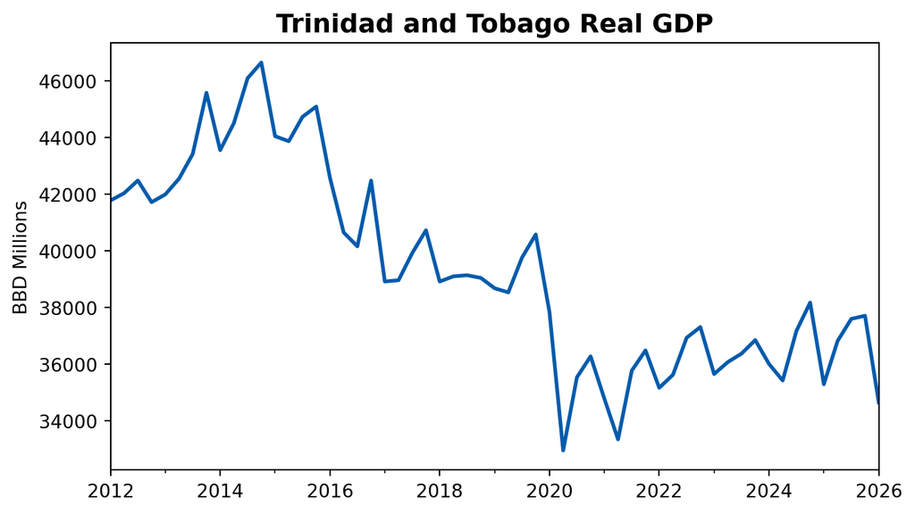

```python
import pandas as pd
import matplotlib.pyplot as plt

df = pd.read_csv("../data/data.csv", parse_dates=["date"], index_col="date")
gdp = df["RGDP0000"].dropna()

gdp.plot(color="#005BAC", linewidth=2, figsize=(7, 4))
plt.title("Trinidad and Tobago Real GDP", fontsize=14, weight="bold")
plt.ylabel("BBD Millions")
plt.xlabel("")
plt.tight_layout()
plt.show()
```

## Selecting and Filtering

```python
import pandas as pd
df = pd.read_csv("../data/data.csv", parse_dates=["date"], index_col="date")

# Select one column
gdp = df["RGDP0000"].dropna()

# Filter to post-2018
recent = gdp[gdp.index >= "2018-01-01"]

# Describe
recent.describe()
```

```
count       33.000000
mean     36830.546048
std       1803.151863
min      32947.738020
25%      35618.229344
50%      36811.895707
75%      38169.391339
max      40574.574919
Name: RGDP0000, dtype: float64
```

### Complex Filtering

```python
import pandas as pd
df = pd.read_csv("../data/data.csv", parse_dates=["date"], index_col="date")
gdp = df["RGDP0000"].dropna()

# Keep only recession quarters (negative growth)
gdp_growth = gdp.pct_change() * 100
recession = gdp_growth[gdp_growth < 0]
print(recession)
```

```
date
2012-12-01    -1.805810
2014-03-01    -4.447075
2015-03-01    -5.574826
2015-06-01    -0.406211
2016-03-01    -5.570410
2016-06-01    -4.539009
2016-09-01    -1.209665
2017-03-01    -8.394277
2018-03-01    -4.444473
2018-12-01    -0.241861
2019-03-01    -0.932171
2019-06-01    -0.379276
2020-03-01    -6.749284
2020-06-01   -12.919793
2021-03-01    -4.111920
2021-06-01    -4.143239
2022-03-01    -3.619164
2023-03-01    -4.449139
2024-03-01    -2.280938
2024-06-01    -1.634006
2025-03-01    -7.553301
2026-03-01    -8.112120
Name: RGDP0000, dtype: float64
```

## Combining Datasets: concat, merge, join

| Method | Use | Based On | Example | Notes |
| --- | --- | --- | --- | --- |
| **`pd.concat()`** | Stack rows or columns | Axis | `pd.concat([df1, df2])` | Simple append |
| **`pd.merge()`** | SQL-style JOIN on key columns | Key columns | `pd.merge(df1, df2, on="date")` | Most flexible |
| **`df.join()`** | Combine on index | Index | `df1.join(df2)` | Convenient for time series |

### Merge Example

```python
import pandas as pd

df = pd.read_csv("../data/data.csv", parse_dates=["date"], index_col="date")

# Select GDP and Google Trends index
gdp   = df[["RGDP0000"]].dropna()
gtrends = df[["UGTR0000"]].dropna()

# Merge on date index
merged = gdp.join(gtrends, how="inner")
merged.tail(6)
```

| date | RGDP0000 | UGTR0000 |
| --- | --- | --- |
| 2024-12-01 | 38169.391339 | 48.333333 |
| 2025-03-01 | 35286.342226 | 48.500000 |
| 2025-06-01 | 36811.895707 | 41.583333 |
| 2025-09-01 | 37594.126550 | 48.500000 |
| 2025-12-01 | 37703.621567 | 47.791667 |
| 2026-03-01 | 34645.058555 | 48.291667 |

## Reshaping

### wide → long: `melt()`

```python
long_df = df.melt(id_vars="date",
                  value_vars=["RGDP0000", "UGTR0000"],
                  var_name="variable",
                  value_name="value")
long_df.head()
```

### long → wide: `pivot()`

```python
wide_df = long_df.pivot(index="date", columns="variable", values="value")
wide_df.head()
```

### Resample

Transforms data to a different frequency (e.g. monthly → quarterly):

```python
import pandas as pd
import matplotlib.pyplot as plt

df = pd.read_csv("../data/data.csv", parse_dates=["date"], index_col="date")

# Google Trends — monthly
gt_monthly = df["UGTR0000"].dropna()

# Resample to quarterly mean
gt_quarterly = gt_monthly.resample("QS").mean()

plt.figure(figsize=(8, 4))
plt.plot(gt_monthly.index, gt_monthly, alpha=0.4, label="Monthly")
plt.plot(gt_quarterly.index, gt_quarterly, color="red",
         linewidth=2, label="Quarterly")
plt.legend(frameon=False)
plt.title("Google Trends Index — Monthly vs Quarterly")
plt.show()
```

[output not shown]

### Resample Frequencies

[output not shown]

# Activity

## Your first notebook

Open **`public/activity/act1_python_basics.ipynb`** (kernel: `nwcst`).

You will load a real dataset, inspect it, filter it, merge two sources, and reshape between wide and long. Everything in this session, applied once.

The R version, `act1_r_basics.R`, comes with the next session (R fundamentals).

**Note**

Stuck on a cell? The worked version is in `public/sols/`. Try it yourself first — reading a solution is much less useful than writing a wrong answer and fixing it.

# Appendix — Visualization

## Line Plot

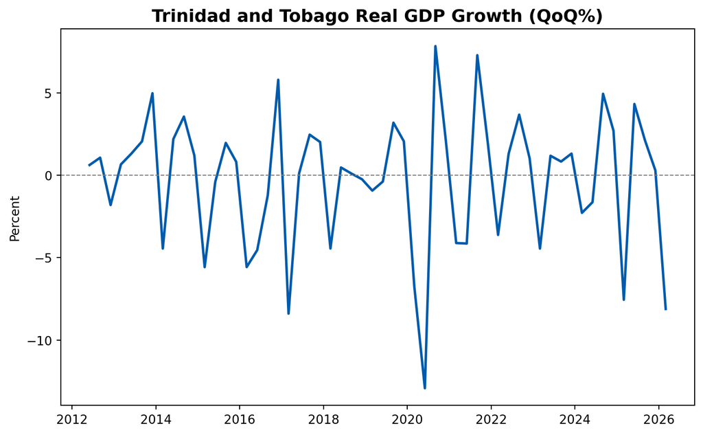

```python
import pandas as pd
import matplotlib.pyplot as plt

df = pd.read_csv("../data/data.csv", parse_dates=["date"], index_col="date")
gdp = df["RGDP0000"].dropna()
gdp_g = gdp.pct_change() * 100

fig, ax = plt.subplots(figsize=(8, 5))
ax.plot(gdp_g.index, gdp_g, color="#005BAC", linewidth=2)
ax.axhline(0, color="grey", linestyle="--", linewidth=0.8)
ax.set_title("Trinidad and Tobago Real GDP Growth (QoQ%)", fontsize=14, weight="bold")
ax.set_ylabel("Percent")
plt.tight_layout()
plt.show()
```

## Bar Chart

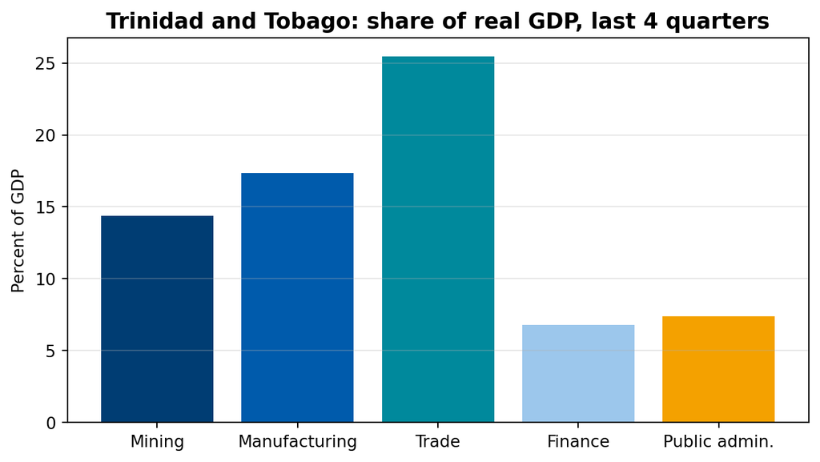

```python
import matplotlib.pyplot as plt

import pandas as pd

# Real gross value added by ISIC section, last four quarters (CBTT)
g = pd.read_csv("../raw/cbtt_gdp.csv", parse_dates=["date"], index_col="date")
names = {"B": "Mining", "C": "Manufacturing", "G": "Trade",
         "K": "Finance", "O": "Public admin."}
gva = g[[f"NGDPVA_R_ISIC4_{k}_XDC" for k in names]].dropna().tail(4).sum()
total = g["NGDP_PA_R_XDC"].dropna().tail(4).sum()
shares = (gva / total * 100).values

fig, ax = plt.subplots(figsize=(7, 4))
ax.bar(list(names.values()), shares,
       color=["#003D73", "#005BAC", "#00899C", "#9CC7EC", "#F4A100"])
ax.set_title("Trinidad and Tobago: share of real GDP, last 4 quarters", fontsize=13, weight="bold")
ax.set_ylabel("Percent of GDP")
ax.grid(axis="y", alpha=0.3)
plt.tight_layout()
plt.show()
```

## Scatter Plot

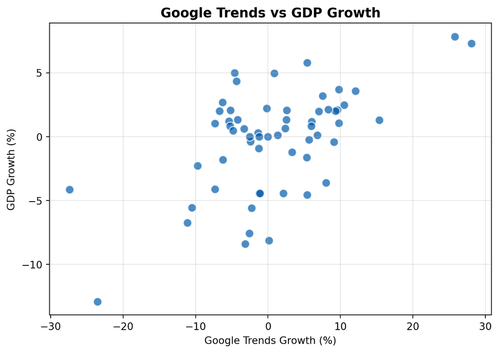

```python
import pandas as pd
import matplotlib.pyplot as plt

df = pd.read_csv("../data/data.csv", parse_dates=["date"], index_col="date")
df_q = df[["RGDP0000", "UGTR0000"]].resample("QS").mean()
df_q = df_q.pct_change().dropna() * 100

fig, ax = plt.subplots(figsize=(7, 5))
ax.scatter(df_q["UGTR0000"], df_q["RGDP0000"],
           s=70, color="#005BAC", alpha=0.7, edgecolors="white")
ax.set_title("Google Trends vs GDP Growth", fontsize=13, weight="bold")
ax.set_xlabel("Google Trends Growth (%)")
ax.set_ylabel("GDP Growth (%)")
ax.grid(alpha=0.3)
plt.tight_layout()
plt.show()
```